# NBA Report - 2025 Season

Joey, Eduardo, Shizu, Megan, and Ella

Apr 21, 2025

# Introduction

Our report breaks down some NBA data from the 2025 season. Given the variation in the number of minutes a player gets each game, we are looking at statistics per-36 minutes. These numbers are not equivalent to the box score numbers that same player would tally in an actual game. Data from this report are based on numbers through Mar 07, 2025.

## Section 1 (Eduardo)

Points, assists, and rebounds are the three major statistical categories in basketball. Only three active NBA players have ever won a championship while leading their team in all three categories that same season - LeBron James, Nikola Jokic, and Jayson Tatum.

We decided to tally a combined score of (points + assists + rebounds) to identify the 10 players with the highest combined score for the 2025 season, using per-36 minute statistics. As expected, many of the top players in the NBA appear in this table.

Top 10 NBA Players based on Per 36-Minute Score<sup>1</sup>

| Player Name | Performance Points | Performance Assists | Performance Rebounds | Performance Score |
| --- | --- | --- | --- | --- |
| Alondes Williams | 45.0 | 9.0 | 0.0 | 54.0 |
| Giannis Antetokounmpo | 32.7 | 6.3 | 12.9 | 51.9 |
| Nikola Jokić | 28.7 | 10.3 | 12.7 | 51.7 |
| James Wiseman | 43.2 | 0.0 | 7.2 | 50.4 |
| Zion Williamson | 31.2 | 6.5 | 9.4 | 47.1 |
| Shai Gilgeous-Alexander | 34.5 | 6.5 | 5.4 | 46.4 |
| Luka Dončić | 27.6 | 8.2 | 8.5 | 44.3 |
| Anthony Davis | 27.1 | 3.6 | 12.6 | 43.3 |
| Joel Embiid | 28.3 | 5.3 | 9.7 | 43.3 |
| LeBron James | 25.8 | 8.8 | 8.4 | 43.0 |

<sup>1</sup> Score is a direct sum of points, assists, and rebounds.

## Section 2 (Megan)

Our team also created a scatter plot that shows the association between a player’s age and rank in the NBA. The y-axis for this plot was flipped so that the players who are ranked the highest are at the top of the graph, and those that are ranked the lowest are at the bottom.

A line of best fit was applied to display the general trend. On average, a player’s rank improves as they get older and gain more experience in the league.

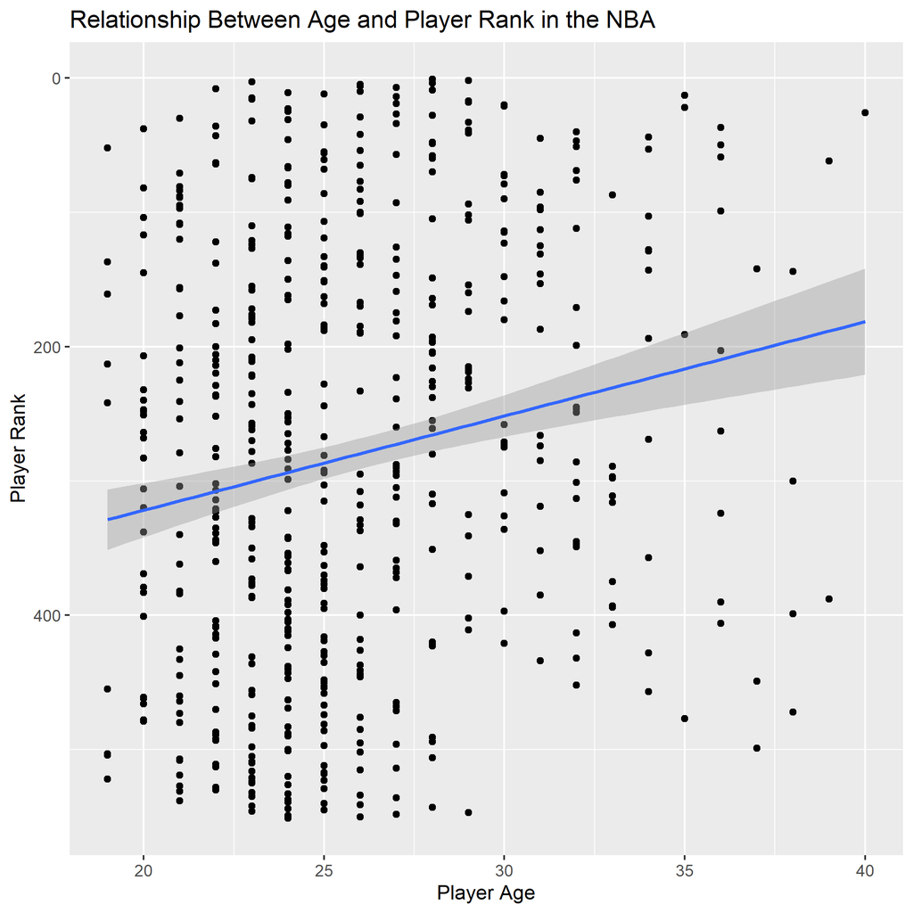

## Section 3 (Ella)

We decided to customize the report to look closely at the scoring ability of Yuki Kawamura, Rui Hachimura, and James Harden, three of our favorite players in the NBA. We compare their points per-36 minutes to the league average for the 2025 season.

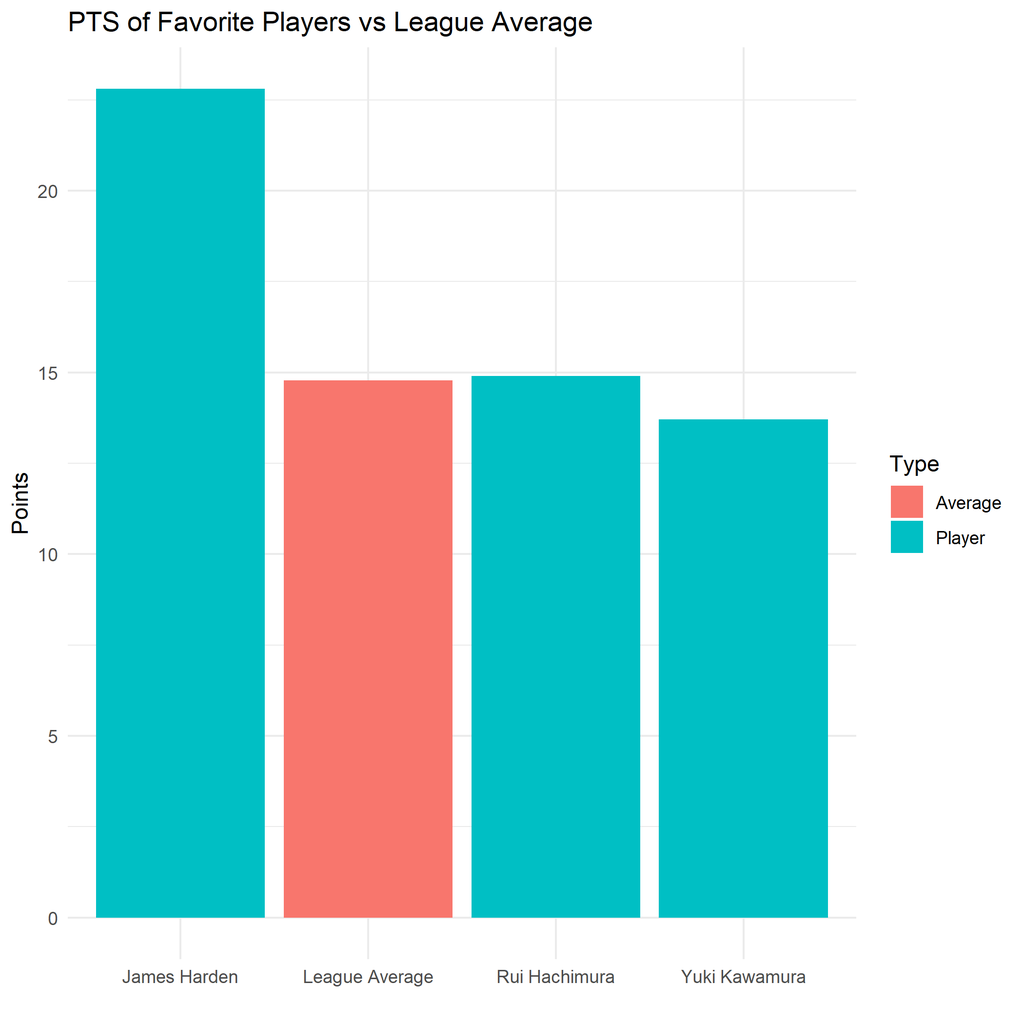

## Section 4 (Shizu)

Below, we look at the same three players seen in section 3: Yuki Kawamura, Rui Hachimura, and James Harden. We now look at their points per-36 minutes individually, without including the league average as a reference group.

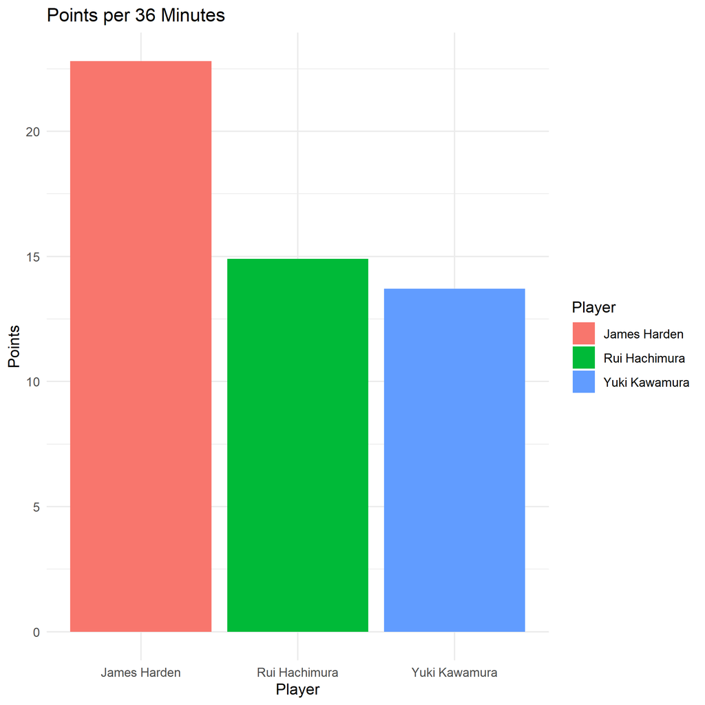

## Conclusion

Our report uses NBA data to assess performance in different ways. We looked at a combined score of (points + assists + rebounds), a plot of age vs. rank, and then a closer look at points for some specific players. One limitation of this report is that per-36 minute stats do not always approximate a player’s true box score numbers. The best players often play over closer to 40 minutes per game, so their stats may appear less impressive. On the opposite end, fringe rotation players who get very few minutes will have their stats inflated. Nevertheless, per-36 minute numbers are a good proxy for player performance.